# Corpus Analysis Masterclass

[figure not shown]

### Mark Alfano & Brian Ballsun-Stanton, Macquarie University

> …when you're talking about **intelligence** you're talking about **number**. A claim that the mathless are quick to frown upon. It's about calculation and the nature of calculation. **Verbal intelligence will only take you so far.** There is a wall there, and if you don't understand numbers you won't even see the wall. People from the other side will seem odd to you. And you will never understand the latitude which they extend to you. They will be cordial — or not — depending on their nature. Of course one might also add that **intelligence is a basic component of evil**. The more stupid you are the less capable you are of doing harm. Except perhaps in a clumsy and inadvertent manner. The word cretin comes from the French *chrétien*. Supposedly if you could think of nothing good to say about a dullard you would say that he was a good Christian. Diabolical on the other hand is all but synonymous with ingenious. **What Satan had for sale in the garden was knowledge.**

> ~Cormac McCarthy, *Stella Maris*

### WELCOME!

*Hell is empty, and all the devils are here…*

## Agenda

- **Day 1 AM (Mark):** introductions, examples of what's to come, Python install verification
- **Day 1 PM (Brian):** follow-along typing; your first word cloud and hierarchical clustering
- **Day 2 AM (Brian):** demos of various corpus analyses we've done
- **Day 2 PM (Mark):** (re)introduction to document-feature matrices; matrices and their multiplication; collocation networks
- **Day 3 AM (Mark):** more corpus work and LIWC, this time in German!
- **Day 3 PM (Brian):** follow-along typing; building your own custom dictionary
- **Day 4 AM (Brian/Mark): Splitting class:** finding and constructing corpora with AI | how to download things other people have built
- **Day 4 PM (Brian/Mark):** brainstorming, planning collaborations, goodbyes

## brief round of introductions…

- name
- affiliation
- one embarrassing fact about yourself
- background (if any) with coding or corpus methods
- what you hope to get out of this masterclass

## Sticky Note protocol

- **Green** sticky note on your laptop: *"I'm done and my code has run successfully."*
- **No** sticky note: *"Currently working on it!"*
- **Red** sticky note: *"I'd like some help"* – the person not speaking will head over to help you

## Files (code, corpora, etc.) available here:

**https://github.com/DH-Oz/CorpusAnalysis/releases**

### Some notes for total beginners (and anyone who needs a reminder):

- Writing **code** is not like writing **prose**!
- If you write a **shitty sentence**, you can move on, come back to it later, and edit.
- If you write a **shitty line of code**, it will probably fail catastrophically.
- The reinforcement schedule for writing prose is a **slow, reliable drip** (word word word word…). You can see your progress as you make it.
- The reinforcement schedule for writing code is **punctuated and irregular** (fail fail fail success! fail fail fail FAIL fail fail success! fail fail fail); note that irregular reinforcement schedules are associated with **addiction** (e.g., gambling).
- **Google** your error messages! You're almost certainly not the first person to run into this problem.
- Maybe the problem is that the **working directory** isn't set correctly, or you just need to **update** your Python or conda packages – or just **restart** Jupyter.
- **Stack Overflow** is your friend, but only post there if you can give them a **minimal, reproducible example**; otherwise they will be **very very mean** to you.
- Perhaps most importantly, most code is **not always built from scratch but copy-pasted, then tailored to purpose**.

# Day 1 AM: Intro

[figure not shown]

# Installing Python

## Installing the Python environment:

- **Miniconda** (or Anaconda): https://docs.conda.io/en/latest/miniconda.html
- **Jupyter**: bundled with Miniconda.
- **This course's env**: download the release zip, then in the unpacked folder run `conda env create -f environment.yml` and `conda activate corpusanalysis`
- **For locked-down machines**: open the notebooks in Google Colab.
- **For Linux**: talk to Brian

*Always look on the bright side of code.*

## Verify your Python environment

The cell below is a Python **code cell**. Click inside it, then press **Shift+Enter** to run. The kernel evaluates the code; the output appears underneath.

```python
print("Hello, corpus!")
```

```
Hello, corpus!
```

The course uses the libraries below. An `ImportError` means the conda environment is incomplete.

```python
import nltk
import numpy
import pandas
import matplotlib
import sklearn
import scipy
import wordcloud
import networkx
import spacy

print("All libraries imported successfully.")
```

```
All libraries imported successfully.
```

NLTK data ships separately from the library. The download caches after the first run.

```python
import nltk

nltk.download("punkt")
nltk.download("punkt_tab")
nltk.download("stopwords")

print("NLTK data ready.")
```

```
NLTK data ready.
```

spaCy needs pre-trained language models. The small English and German models ship in `environment.yml`.

```python
import spacy

nlp_en = spacy.load("en_core_web_sm")
nlp_de = spacy.load("de_core_news_sm")

print(f"English model loaded: {nlp_en.meta['name']}")
print(f"German model loaded:  {nlp_de.meta['name']}")
```

```
English model loaded: core_web_sm
German model loaded:  core_news_sm
```

Custom open dictionaries for the masculinity and rhetoric work ship in the release zip.

```python
import os

dict_dir = "dictionaries"
for name in ["nietzsche.dic", "macdvirtue.dic", "nuke.dic"]:
    path = os.path.join(dict_dir, name)
    print(f"{name}: {'OK' if os.path.exists(path) else 'MISSING'}")
```

```
nietzsche.dic: OK
macdvirtue.dic: OK
nuke.dic: OK
```

## Your first corpus analysis…

Follow along: `corpusmasterclass0.ipynb`

## State of the Union addresses

- From 1790 to present
- Yearly (unlike inaugurals)
- Mixed format (written vs spoken)
- Varying lengths (1k-35k)
- Available natively in the `sotu` Python package

[figure not shown]

```python
import sotu

df = sotu.load()
print(f"Loaded {len(df)} SoU addresses, {df['year'].min()}–{df['year'].max()}.")
print(f"\nFirst three rows:")
print(df.head(3)[["year", "president", "party", "sotu_type"]])
print(f"\nLast three rows:")
print(df.tail(3)[["year", "president", "party", "sotu_type"]])
```

```
Loaded 237 SoU addresses, 1790–2026.

First three rows:
   year   president        party sotu_type
0  1790  Washington  Nonpartisan    spoken
1  1790  Washington  Nonpartisan    spoken
2  1791  Washington  Nonpartisan    spoken

Last three rows:
     year president       party sotu_type
234  2023     Biden  Democratic    spoken
235  2024     Biden  Democratic    spoken
236  2026     Trump  Republican    spoken
```

## Washington-1790

```python
first_row = df.iloc[0]
preview_chars = 900
print(f"{first_row['year']} {first_row['president']} ({first_row['sotu_type']}) — first {preview_chars} characters:\n")
print(first_row["text"][:preview_chars] + " …")
```

[output not shown]

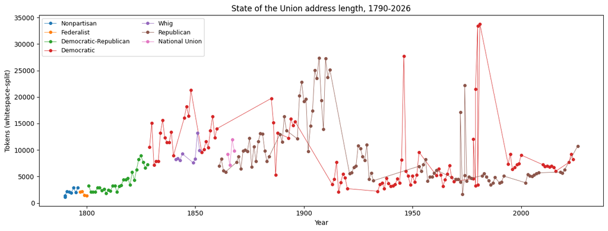

```python
import matplotlib.pyplot as plt

token_counts = []
for text in df["text"]:
    token_counts.append(len(text.split()))

df_plot = df.copy()
df_plot["tokens"] = token_counts

fig, ax = plt.subplots(figsize=(13, 5))
for party in df_plot["party"].unique():
    sub = df_plot[df_plot["party"] == party].sort_values("year")
    ax.plot(sub["year"], sub["tokens"], marker="o", linewidth=0.6, markersize=4, label=party)
ax.set_xlabel("Year")
ax.set_ylabel("Tokens (whitespace-split)")
ax.set_title("State of the Union address length, 1790-2026")
ax.legend(loc="upper left", fontsize=9, ncol=2)
plt.tight_layout()
plt.show()
```

```python
import sklearn.feature_extraction.text
import pandas

labels = []
for year, pres in zip(df["year"], df["president"]):
    labels.append(f"{year}-{pres}")

vectorizer = sklearn.feature_extraction.text.CountVectorizer(lowercase=True, stop_words="english")
dfm = vectorizer.fit_transform(df["text"])
features = vectorizer.get_feature_names_out()

dfm_df = pandas.DataFrame(dfm.toarray(), index=labels, columns=features)
print(f"DFM shape: {dfm.shape[0]} docs × {dfm.shape[1]} features\n")
print("Head (first 6 docs, first 8 features):")
print(dfm_df.iloc[:6, :8])

totals = dfm_df.sum(axis=0).sort_values(ascending=False)
print("\nTop 15 features across the whole corpus:")
print(totals.head(15))
```

```
DFM shape: 237 docs × 26013 features

Head (first 6 docs, first 8 features):
                 00  000  0000  0001  000m  000page  001  002
1790-Washington   0    0     0     0     0        0    0    0
1790-Washington   0    2     0     0     0        0    0    0
1791-Washington   0    5     0     0     0        0    0    0
1792-Washington   0    2     0     0     0        0    0    0
1793-Washington   0    4     0     0     0        0    0    0
1794-Washington   0    0     0     0     0        0    0    0

Top 15 features across the whole corpus:
government    7629
states        6948
congress      5821
united        5170
year          4839
people        4458
country       3727
new           3534
great         3494
public        3408
000           3218
time          3180
american      3014
war           2952
world         2842
dtype: int64
```

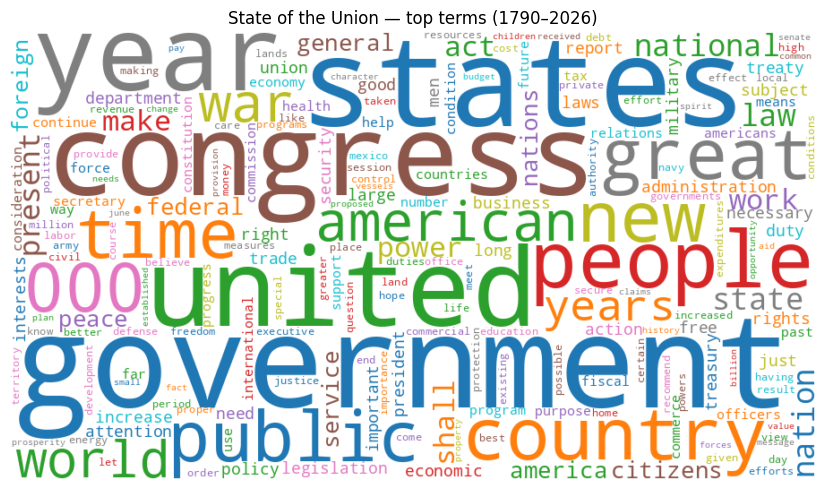

```python
import wordcloud

word_freq = {}
for word, total in totals.items():
    word_freq[word] = int(total)

wc = wordcloud.WordCloud(width=900, height=500, background_color="white", colormap="tab10", random_state=42)
wc.generate_from_frequencies(word_freq)

fig, ax = plt.subplots(figsize=(10, 5))
ax.imshow(wc, interpolation="bilinear")
ax.axis("off")
ax.set_title("State of the Union — top terms (1790–2026)")
plt.tight_layout()
plt.show()
```

[figure not shown]

## ColorBrewer palettes via matplotlib

Matplotlib ships the ColorBrewer palettes as named colormaps. Anything you'd pick on `colorbrewer2.org` is reachable by name (`"Blues"`, `"YlGnBu"`, `"Set1"`, …).

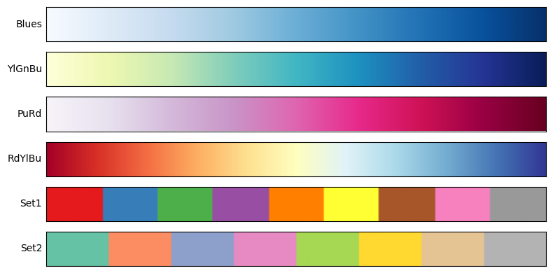

```python
import matplotlib

palette_names = ["Blues", "YlGnBu", "PuRd", "RdYlBu", "Set1", "Set2"]
fig, axes = plt.subplots(len(palette_names), 1, figsize=(8, 4))
for ax, name in zip(axes, palette_names):
    gradient = [[i / 255 for i in range(256)]]
    ax.imshow(gradient, aspect="auto", cmap=matplotlib.colormaps[name])
    ax.set_yticks([])
    ax.set_xticks([])
    ax.set_ylabel(name, rotation=0, ha="right", va="center")
plt.tight_layout()
plt.show()
```

## Topic modeling using Latent Dirichlet Allocation

```python
import sklearn.decomposition

n_topics = 8
n_terms = 7
lda = sklearn.decomposition.LatentDirichletAllocation(n_components=n_topics, random_state=42, max_iter=20)
lda.fit(dfm)

topics = {}
for topic_idx, topic_weights in enumerate(lda.components_):
    top_term_indices = topic_weights.argsort()[-n_terms:][::-1]
    topics[f"Topic {topic_idx + 1}"] = [features[i] for i in top_term_indices]

topics_df = pandas.DataFrame(topics)
print(f"{n_topics} topics × top {n_terms} terms each:\n")
print(topics_df)
```

```
8 topics × top 7 terms each:

     Topic 1     Topic 2     Topic 3   Topic 4     Topic 5 Topic 6  \
0    america      united  government  congress      states   thank
1     people  government       great     world  government    eric
2   american      states      people      year      united  really
3        new       canal         law   federal    congress     got
4  americans     islands         men       new      public   going
5      years        cuba     country  economic     country     amy
6      world      island      public   program       great   great

      Topic 7     Topic 8
0         war         000
1        year  government
2         new        year
3    congress      states
4  government    congress
5     federal      united
6     million     service
```

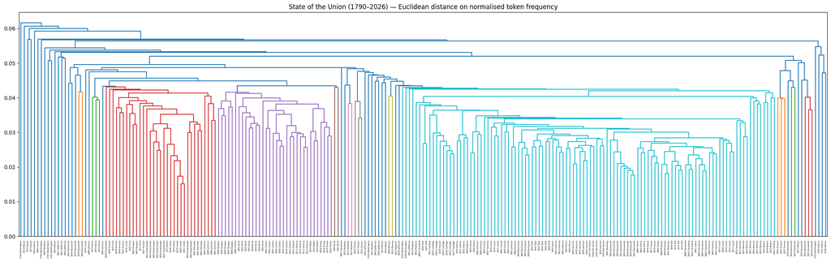

```python
import scipy.cluster.hierarchy
import scipy.spatial.distance
import numpy

dfm_dense = dfm.toarray().astype(float)
row_totals = dfm_dense.sum(axis=1, keepdims=True)
row_totals[row_totals == 0] = 1.0
normalised = dfm_dense / row_totals

distances = scipy.spatial.distance.pdist(normalised, metric="euclidean")
linkage = scipy.cluster.hierarchy.linkage(distances, method="average")

fig, ax = plt.subplots(figsize=(22, 7))
scipy.cluster.hierarchy.dendrogram(linkage, labels=labels, leaf_rotation=90, leaf_font_size=4, ax=ax)
ax.set_title("State of the Union (1790–2026) — Euclidean distance on normalised token frequency")
plt.tight_layout()
plt.show()
```

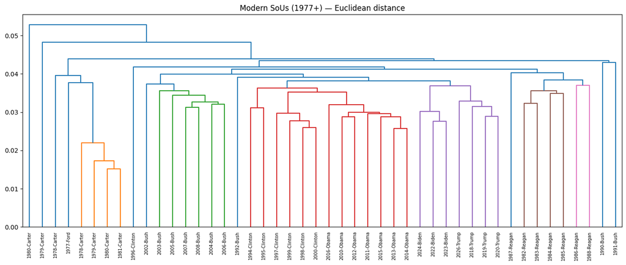

```python
modern_cutoff = 1977
modern_mask = df["year"] >= modern_cutoff
modern_matrix = normalised[modern_mask.values]
modern_labels = []
for label, keep in zip(labels, modern_mask.values):
    if keep:
        modern_labels.append(label)

modern_distances = scipy.spatial.distance.pdist(modern_matrix, metric="euclidean")
modern_linkage = scipy.cluster.hierarchy.linkage(modern_distances, method="average")

fig, ax = plt.subplots(figsize=(14, 6))
scipy.cluster.hierarchy.dendrogram(modern_linkage, labels=modern_labels, leaf_rotation=90, leaf_font_size=7, ax=ax)
ax.set_title(f"Modern SoUs ({modern_cutoff}+) — Euclidean distance")
plt.tight_layout()
plt.show()
```

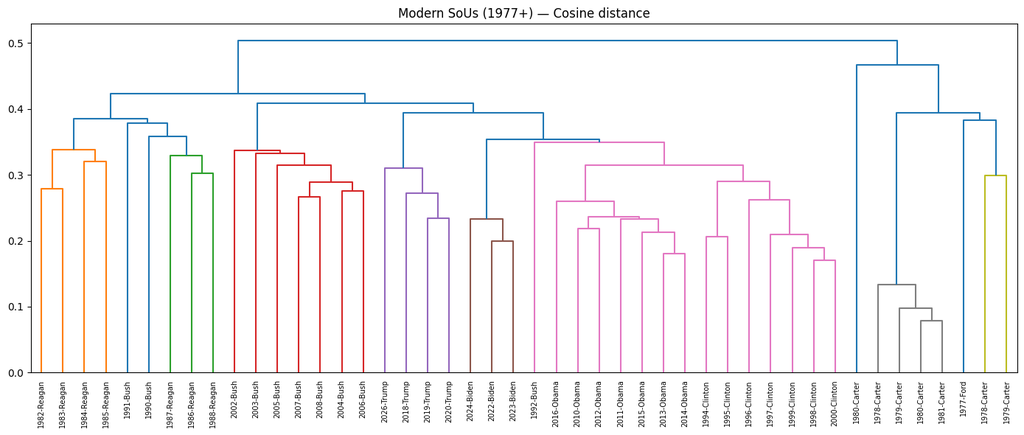

```python
cosine_distances = scipy.spatial.distance.pdist(modern_matrix, metric="cosine")
cosine_linkage = scipy.cluster.hierarchy.linkage(cosine_distances, method="average")

fig, ax = plt.subplots(figsize=(14, 6))
scipy.cluster.hierarchy.dendrogram(cosine_linkage, labels=modern_labels, leaf_rotation=90, leaf_font_size=7, ax=ax)
ax.set_title(f"Modern SoUs ({modern_cutoff}+) — Cosine distance")
plt.tight_layout()
plt.show()
```

[figure not shown]

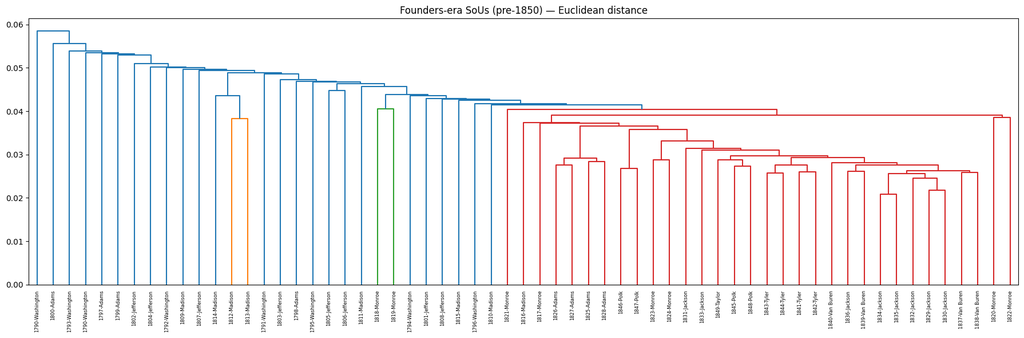

```python
older_cutoff = 1850
older_mask = df["year"] < older_cutoff
older_matrix = normalised[older_mask.values]
older_labels = []
for label, keep in zip(labels, older_mask.values):
    if keep:
        older_labels.append(label)

older_distances = scipy.spatial.distance.pdist(older_matrix, metric="euclidean")
older_linkage = scipy.cluster.hierarchy.linkage(older_distances, method="average")

fig, ax = plt.subplots(figsize=(18, 6))
scipy.cluster.hierarchy.dendrogram(older_linkage, labels=older_labels, leaf_rotation=90, leaf_font_size=6, ax=ax)
ax.set_title(f"Founders-era SoUs (pre-{older_cutoff}) — Euclidean distance")
plt.tight_layout()
plt.show()
```

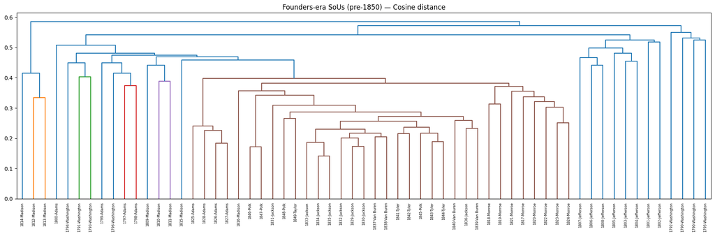

```python
older_cosine = scipy.spatial.distance.pdist(older_matrix, metric="cosine")
older_cosine_link = scipy.cluster.hierarchy.linkage(older_cosine, method="average")

fig, ax = plt.subplots(figsize=(18, 6))
scipy.cluster.hierarchy.dendrogram(older_cosine_link, labels=older_labels, leaf_rotation=90, leaf_font_size=6, ax=ax)
ax.set_title(f"Founders-era SoUs (pre-{older_cutoff}) — Cosine distance")
plt.tight_layout()
plt.show()
```

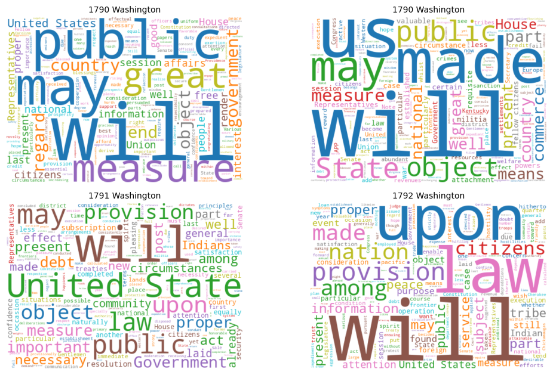

```python
comparison_clouds("Washington")
```

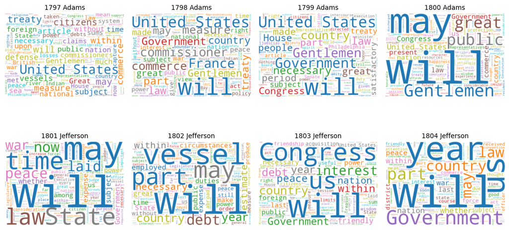

```python
comparison_clouds(["Adams", "Jefferson"])
```

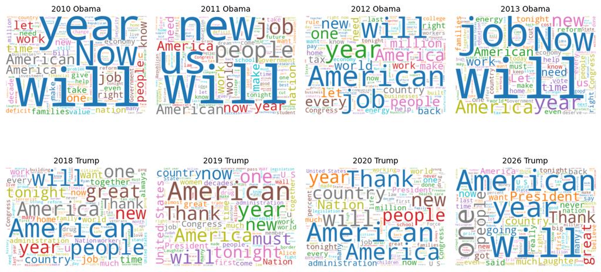

```python
comparison_clouds(["Obama", "Trump"])
```

## Before we end, sticky note feedback

- On the green sticky note, write one thing that went well this session.
- On the red sticky note, write one thing that we can improve on, tomorrow.

# Thanks for your attention!